# Crosscheck - skinoptics.colors and colour-science

Victor Lima  
victorporto@ifsc.usp.br  
victor.lima@ufscar.br  
[victorportog.github.io](https://victorportog.github.io/index.html)

Release date:  
01 April 2025  
Last modification:  
01 April 2025

This notebook compares the skinoptics.colors module with the colour-science package (https://www.colour-science.org/) for numerical calculations of CIE XYZ, sRGB and CIE L*a*b* color space coordinates from human skin reflectance spectra.

The skin reflectance spectra used here are from the [publicly available database by Xiao et al.](https://www.color.org/groups/medical/skin/skin_colour.xalter) [X*16].

All calculations were performed assuming the CIE standard illuminant D65 and the CIE 10 degree standard observer (except for the sRGB coordinates, for which the CIE standard illuminant D65 and the CIE 2 degree standard observer were assumed, as default).

CIE XYZ coordinates were computed by numerical integration of the reflectance spectrum in the region between 360 and 830 nm. A cubic spline interpolation was carried out from 360 to 740 nm and a constant extrapolation was carried out from 740 to 830 nm. Then, sRGB and CIE L*a*b* coordinates were obtained from CIE XYZ coordinates.

This file is part of [SkinOptics documentation](https://skinoptics.readthedocs.io/en/latest/index.html).

References:

[X*16] Xiao, Zhu, Li, Connah, Yates & Wuerger 2016.  
Improved method for skin reflectance reconstruction from camera images.  
https://doi.org/10.1364/OE.24.014934

[F23] Feranández-Barral 2023.  
Best practices for colour blind friendly publications & descriptions.  
https://pos.sissa.it/guidelines.pdf

```python
import time
import numpy as np
import matplotlib
from matplotlib import rcParams, style
import matplotlib.pyplot as plt
import pandas as pd
```

```python
print('numpy version:', np.__version__)
print('matplotlib version:', matplotlib.__version__)
print('pandas version:', pd.__version__)
```

```
numpy version: 1.26.4
matplotlib version: 3.9.0
pandas version: 2.2.2
```

```python
rcParams.update({'font.size': 12})
rcParams.update({'axes.labelsize': 12})
rcParams.update({'axes.titlesize': 12})
rcParams.update({'xtick.labelsize': 12})
rcParams.update({'ytick.labelsize': 12})
rcParams.update({'legend.fontsize': 10})
rcParams.update({'axes.grid': True})
plt.rcParams["figure.figsize"] = (6, 4)
```

```python
color_cycle =  ['#CC78BC', '#029E73', '#56B4E9']
```

A bigger font size (12.) than plt deafult (10.) was set and some colors from 'seaborn-colorbind' palette were chosen.  
This color palette may be more inclusive for people with color vision deficiencies [F23].

## Importing tools from skinoptics.colors and colour-science

```python
import skinoptics
import colour
from skinoptics.colors import *
from colour import *
```

```python
print('skinoptics version:', skinoptics.__version__)
print('colour-science version:', colour.__version__)
```

```
skinoptics version: 0.0.1
colour-science version: 0.4.6
```

## Getting data from the database by Xiao et al. 2016

```python
all_lambda = np.arange(360, 740 + 10, 10)
path = os.getcwd()
parent_path = os.path.dirname(path)
reflectance = np.array(pd.read_excel(parent_path + '\skinoptics\datasets\spectra\Xiao2016\skindatabaseSpectra\skin spectra data.xlsx'))[:,1:]
n = len(reflectance)
print(n)
```

```
4392
```

## Visualizing the cubic spline interpolation and the constant extrapolation

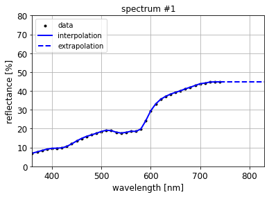

```python
plt.scatter(all_lambda, reflectance[0,:]*100, color = 'k', marker = '.', label = 'data')
plt.plot(all_lambda, interp1d(all_lambda, reflectance[0,:]*100, kind = 'cubic',
                              bounds_error = False,
                              fill_value = (reflectance[0,0]*100, reflectance[0,-1]*100))(all_lambda),
         color = 'b', lw = 2., label = 'interpolation')
x = np.arange(740, 830 + 1, 1)
plt.plot(x, interp1d(all_lambda, reflectance[0,:]*100, kind = 'cubic',
                     bounds_error = False, fill_value = (reflectance[0,0]*100, reflectance[0,-1]*100))(x),
         color = 'b', ls = '--', lw = 2., label = 'extrapolation')
plt.xlabel('wavelength [nm]')
plt.ylabel('reflectance [%]')
plt.title('spectrum #1')
plt.legend(loc = 'upper left')
plt.xlim(360, 830)
plt.ylim(0, 80)
plt.show()
```

## Calculation using skinoptics.colors

```python
X_sc, Y_sc, Z_sc, R_sc, G_sc, B_sc, L_sc, a_sc, b_sc = np.zeros([9, n])
t0 = time.time()
for i in range(n):
    X_sc[i], Y_sc[i], Z_sc[i] = XYZ_from_spectrum(all_lambda, reflectance[i,:]*100)
    R_sc[i], G_sc[i], B_sc[i] = sRGB_from_spectrum(all_lambda, reflectance[i,:]*100)
    L_sc[i], a_sc[i], b_sc[i] = Lab_from_spectrum(all_lambda, reflectance[i,:]*100)
print('execution time: {} seconds (skinoptics.colors)'.format(round(time.time() - t0, 2)))
```

```
execution time: 24.65 seconds (skinoptics.colors)
```

## Calculation using colour-science

```python
X_cs, Y_cs, Z_cs, R_cs, G_cs, B_cs, L_cs, a_cs, b_cs = np.zeros([9, n])
t0 = time.time()
for i in range(n):
    sd = SpectralDistribution(dict_from_arrays(array_keys = all_lambda, array_values = reflectance[i, :]), name = 'Sample')
    cmfs2 = MSDS_CMFS['CIE 1931 2 Degree Standard Observer']
    cmfs10 = MSDS_CMFS['CIE 1964 10 Degree Standard Observer']
    illuminant = SDS_ILLUMINANTS['D65']
    X_cs[i], Y_cs[i], Z_cs[i] = sd_to_XYZ(sd, cmfs10, illuminant)/100
    R_cs[i], G_cs[i], B_cs[i] = XYZ_to_sRGB(sd_to_XYZ(sd, cmfs2, illuminant)/100)
    L_cs[i], a_cs[i], b_cs[i] = XYZ_to_Lab(sd_to_XYZ(sd, cmfs10, illuminant)/100,
                                           illuminant = CCS_ILLUMINANTS["CIE 1964 10 Degree Standard Observer"]["D65"])
print('execution time: {} seconds (colour-science)'.format(round(time.time() - t0, 2)))
```

```
execution time: 11.9 seconds (colour-science)
```

## Comparing CIE XYZ coordinates

```python
rel_diff_X_sc_cs = np.abs(X_sc/X_cs - 1)
rel_diff_Y_sc_cs = np.abs(Y_sc/Y_cs - 1)
rel_diff_Z_sc_cs = np.abs(Z_sc/Z_cs - 1)
```

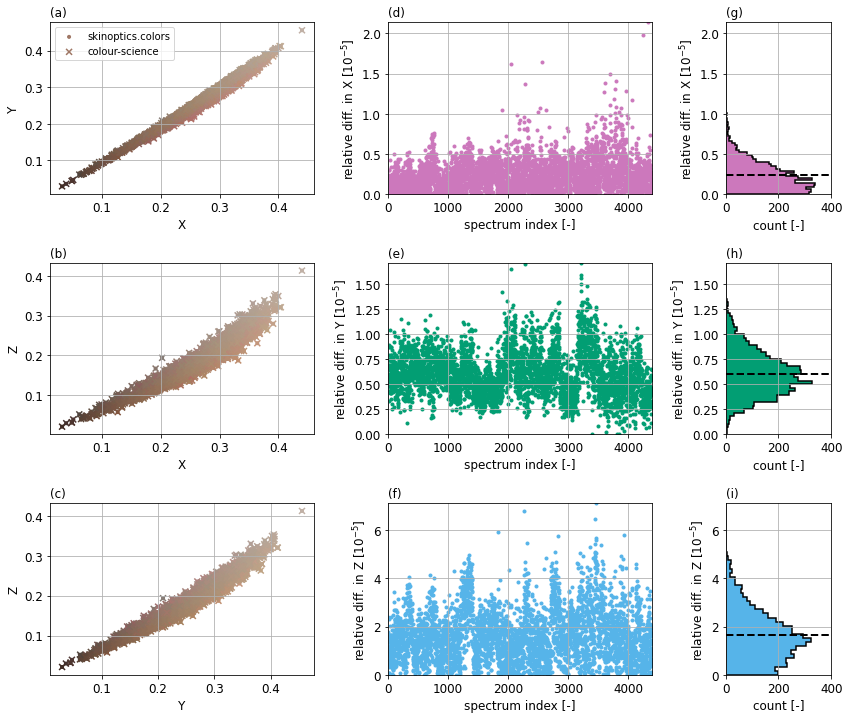

```python
g, axs = plt.subplots(3, 3,
                        gridspec_kw = {'wspace': 0.35, 'hspace': 0.4,
                                       'width_ratios': [2.5, 2.5, 1]}, figsize = (14, 12))

axs[0,0].scatter(X_sc, Y_sc, color = np.dstack((R_sc, G_sc, B_sc))[0,:,:], marker = '.', label = 'skinoptics.colors')
axs[0,0].scatter(X_cs, Y_cs, color = np.dstack((R_cs, G_cs, B_cs))[0,:,:], marker = 'x',label = 'colour-science')
axs[0,0].set_xlabel('X')
axs[0,0].set_ylabel('Y')
axs[0,0].set_title('(a)', loc = 'left')
axs[0,0].legend(loc = 'upper left')

axs[1,0].scatter(X_sc, Z_sc, color = np.dstack((R_sc, G_sc, B_sc))[0,:,:], marker = '.')
axs[1,0].scatter(X_cs, Z_cs, color = np.dstack((R_cs, G_cs, B_cs))[0,:,:], marker = 'x')
axs[1,0].set_xlabel('X')
axs[1,0].set_ylabel('Z')
axs[1,0].set_title('(b)', loc = 'left')

axs[2,0].scatter(Y_sc, Z_sc, color = np.dstack((R_sc, G_sc, B_sc))[0,:,:], marker = '.')
axs[2,0].scatter(Y_cs, Z_cs, color = np.dstack((R_cs, G_cs, B_cs))[0,:,:], marker = 'x')
axs[2,0].set_xlabel('Y')
axs[2,0].set_ylabel('Z')
axs[2,0].set_title('(c)', loc = 'left')

axs[0,1].scatter(np.arange(n), rel_diff_X_sc_cs*1E5, color = color_cycle[0], marker = '.')
axs[0,1].set_xlabel('spectrum index [-]')
axs[0,1].set_ylabel('relative diff. in X [10$^{-5}$]')
axs[0,1].set_title('(d)', loc = 'left')
axs[0,1].set_xlim(0, n)
axs[0,1].set_ylim(0, rel_diff_X_sc_cs.max()*1E5,)

axs[1,1].scatter(np.arange(n), rel_diff_Y_sc_cs*1E5, color = color_cycle[1], marker = '.')
axs[1,1].set_xlabel('spectrum index [-]')
axs[1,1].set_ylabel('relative diff. in Y [10$^{-5}$]')
axs[1,1].set_title('(e)', loc = 'left')
axs[1,1].set_xlim(0, n)
axs[1,1].set_ylim(0, rel_diff_Y_sc_cs.max()*1E5,)

axs[2,1].scatter(np.arange(n), rel_diff_Z_sc_cs*1E5, color = color_cycle[2], marker = '.')
axs[2,1].set_xlabel('spectrum index [-]')
axs[2,1].set_ylabel('relative diff. in Z [10$^{-5}$]')
axs[2,1].set_title('(f)', loc = 'left')
axs[2,1].set_xlim(0, n)
axs[2,1].set_ylim(0, rel_diff_Z_sc_cs.max()*1E5,)

axs[0,2].hist(rel_diff_X_sc_cs*1E5, bins = 'fd', orientation = 'horizontal', lw = 1.5,
              color = color_cycle[0], alpha = 1., edgecolor = 'k', histtype = 'stepfilled')
axs[0,2].hlines(rel_diff_X_sc_cs.mean()*1E5, 0, 400, color = 'k', ls = '--', lw = 2.)
axs[0,2].set_xlabel('count [-]')
axs[0,2].set_ylabel('relative diff. in X [10$^{-5}$]')
axs[0,2].set_title('(g)', loc = 'left')
axs[0,2].set_xlim(0, 400)
axs[0,2].set_ylim(0, rel_diff_X_sc_cs.max()*1E5,)

axs[1,2].hist(rel_diff_Y_sc_cs*1E5, bins = 'fd', orientation = 'horizontal', lw = 1.5,
              color = color_cycle[1], alpha = 1., edgecolor = 'k', histtype = 'stepfilled')
axs[1,2].hlines(rel_diff_Y_sc_cs.mean()*1E5, 0, 400, color = 'k', ls = '--', lw = 2.)
axs[1,2].set_xlabel('count [-]')
axs[1,2].set_ylabel('relative diff. in Y [10$^{-5}$]')
axs[1,2].set_title('(h)', loc = 'left')
axs[1,2].set_xlim(0, 400)
axs[1,2].set_ylim(0, rel_diff_Y_sc_cs.max()*1E5,)

axs[2,2].hist(rel_diff_Z_sc_cs*1E5, bins = 'fd', orientation = 'horizontal', lw = 1.5,
              color = color_cycle[2], alpha = 1., edgecolor = 'k', histtype = 'stepfilled')
axs[2,2].hlines(rel_diff_Z_sc_cs.mean()*1E5, 0, 400, color = 'k', ls = '--', lw = 2.)
axs[2,2].set_xlabel('count [-]')
axs[2,2].set_ylabel('relative diff. in Z [10$^{-5}$]')
axs[2,2].set_title('(i)', loc = 'left')
axs[2,2].set_xlim(0, 400)
axs[2,2].set_ylim(0, rel_diff_Z_sc_cs.max()*1E5,)

plt.show()
```

```python
pd.DataFrame(np.array([[rel_diff_X_sc_cs.mean()*1E5],
                       [rel_diff_Y_sc_cs.mean()*1E5],
                       [rel_diff_Z_sc_cs.mean()*1E5]]),
             index = ['mean relative diff. in X [10$^{-5}$]',
                      'mean relative diff. in Y [10$^{-5}$]',
                      'mean relative diff. in Z [10$^{-5}$]'],
             columns = ['skinoptics.colors & colour-science'])
```

|  | skinoptics.colors & colour-science |
| --- | --- |
| mean relative diff. in X [10$^{-5}$] | 0.239637 |
| mean relative diff. in Y [10$^{-5}$] | 0.604465 |
| mean relative diff. in Z [10$^{-5}$] | 1.636001 |

```python
pd.DataFrame(np.array([[rel_diff_X_sc_cs.max()*1E5],
                       [rel_diff_Y_sc_cs.max()*1E5],
                       [rel_diff_Z_sc_cs.max()*1E5]]),
             index = ['max relative diff. in X [10$^{-5}$]',
                      'max relative diff. in Y [10$^{-5}$]',
                      'max relative diff. in Z [10$^{-5}$]'],
             columns = ['skinoptics.colors & colour-science'])
```

|  | skinoptics.colors & colour-science |
| --- | --- |
| max relative diff. in X [10$^{-5}$] | 2.137114 |
| max relative diff. in Y [10$^{-5}$] | 1.713784 |
| max relative diff. in Z [10$^{-5}$] | 7.118888 |

```python
pd.DataFrame(np.array([[rel_diff_X_sc_cs.min()*1E5],
                       [rel_diff_Y_sc_cs.min()*1E5],
                       [rel_diff_Z_sc_cs.min()*1E5]]),
             index = ['min relative diff. in X [10$^{-5}$]',
                      'min relative diff. in Y [10$^{-5}$]',
                      'min relative diff. in Z [10$^{-5}$]'],
             columns = ['skinoptics.colors & colour-science'])
```

|  | skinoptics.colors & colour-science |
| --- | --- |
| min relative diff. in X [10$^{-5}$] | 0.000164 |
| min relative diff. in Y [10$^{-5}$] | 0.002226 |
| min relative diff. in Z [10$^{-5}$] | 0.000510 |

## Comparing sRGB coordinates

```python
rel_diff_R_sc_cs = np.abs(R_sc/R_cs - 1)
rel_diff_G_sc_cs = np.abs(G_sc/G_cs - 1)
rel_diff_B_sc_cs = np.abs(B_sc/B_cs - 1)
```

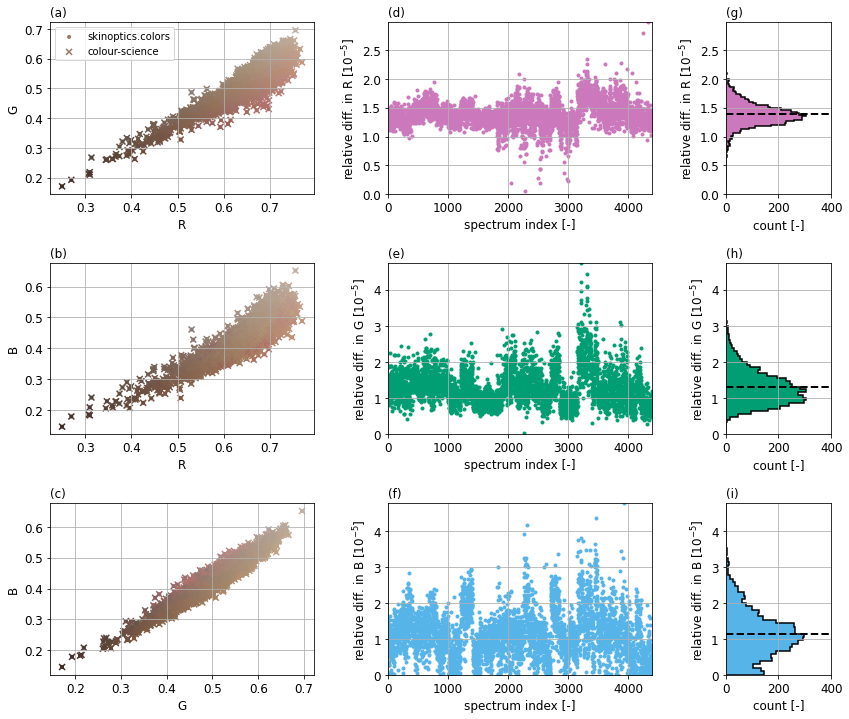

```python
fig, axs = plt.subplots(3, 3,
                        gridspec_kw = {'wspace': 0.35, 'hspace': 0.4,
                                       'width_ratios': [2.5, 2.5, 1]}, figsize = (14, 12))

axs[0,0].scatter(R_sc, G_sc, color = np.dstack((R_sc, G_sc, B_sc))[0,:,:], marker = '.', label = 'skinoptics.colors')
axs[0,0].scatter(R_cs, G_cs, color = np.dstack((R_cs, G_cs, B_cs))[0,:,:], marker = 'x', label = 'colour-science')
axs[0,0].set_xlabel('R')
axs[0,0].set_ylabel('G')
axs[0,0].set_title('(a)', loc = 'left')
axs[0,0].legend(loc = 'upper left')

axs[1,0].scatter(R_sc, B_sc, color = np.dstack((R_sc, G_sc, B_sc))[0,:,:], marker = '.')
axs[1,0].scatter(R_cs, B_cs, color = np.dstack((R_cs, G_cs, B_cs))[0,:,:], marker = 'x')
axs[1,0].set_xlabel('R')
axs[1,0].set_ylabel('B')
axs[1,0].set_title('(b)', loc = 'left')

axs[2,0].scatter(G_sc, B_sc, color = np.dstack((R_sc, G_sc, B_sc))[0,:,:], marker = '.')
axs[2,0].scatter(G_cs, B_cs, color = np.dstack((R_cs, G_cs, B_cs))[0,:,:], marker = 'x')
axs[2,0].set_xlabel('G')
axs[2,0].set_ylabel('B')
axs[2,0].set_title('(c)', loc = 'left')

axs[0,1].scatter(np.arange(n), rel_diff_R_sc_cs*1E5, color = color_cycle[0], marker = '.')
axs[0,1].set_xlabel('spectrum index [-]')
axs[0,1].set_ylabel('relative diff. in R [10$^{-5}$]')
axs[0,1].set_title('(d)', loc = 'left')
axs[0,1].set_xlim(0, n)
axs[0,1].set_ylim(0, rel_diff_R_sc_cs.max()*1E5)

axs[1,1].scatter(np.arange(n), rel_diff_G_sc_cs*1E5, color = color_cycle[1], marker = '.')
axs[1,1].set_xlabel('spectrum index [-]')
axs[1,1].set_ylabel('relative diff. in G [10$^{-5}$]')
axs[1,1].set_title('(e)', loc = 'left')
axs[1,1].set_xlim(0, n)
axs[1,1].set_ylim(0, rel_diff_G_sc_cs.max()*1E5)

axs[2,1].scatter(np.arange(n), rel_diff_B_sc_cs*1E5, color = color_cycle[2], marker = '.')
axs[2,1].set_xlabel('spectrum index [-]')
axs[2,1].set_ylabel('relative diff. in B [10$^{-5}$]')
axs[2,1].set_title('(f)', loc = 'left')
axs[2,1].set_xlim(0, n)
axs[2,1].set_ylim(0, rel_diff_B_sc_cs.max()*1E5)

axs[0,2].hist(rel_diff_R_sc_cs*1E5, bins = 'fd', orientation = 'horizontal', lw = 1.5,
              color = color_cycle[0], alpha = 1., edgecolor = 'k', histtype = 'stepfilled')
axs[0,2].hlines(rel_diff_R_sc_cs.mean()*1E5, 0, 400, color = 'k', ls = '--', lw = 2.)
axs[0,2].set_xlabel('count [-]')
axs[0,2].set_ylabel('relative diff. in R [10$^{-5}$]')
axs[0,2].set_title('(g)', loc = 'left')
axs[0,2].set_xlim(0, 400)
axs[0,2].set_ylim(0, rel_diff_R_sc_cs.max()*1E5)

axs[1,2].hist(rel_diff_G_sc_cs*1E5, bins = 'fd', orientation = 'horizontal', lw = 1.5,
              color = color_cycle[1], alpha = 1., edgecolor = 'k', histtype = 'stepfilled')
axs[1,2].hlines(rel_diff_G_sc_cs.mean()*1E5, 0, 400, color = 'k', ls = '--', lw = 2.)
axs[1,2].set_xlabel('count [-]')
axs[1,2].set_ylabel('relative diff. in G [10$^{-5}$]')
axs[1,2].set_title('(h)', loc = 'left')
axs[1,2].set_xlim(0, 400)
axs[1,2].set_ylim(0, rel_diff_G_sc_cs.max()*1E5)

axs[2,2].hist(rel_diff_B_sc_cs*1E5, bins = 'fd', orientation = 'horizontal', lw = 1.5,
              color = color_cycle[2], alpha = 1., edgecolor = 'k', histtype = 'stepfilled')
axs[2,2].hlines(rel_diff_B_sc_cs.mean()*1E5, 0, 400, color = 'k', ls = '--', lw = 2.)
axs[2,2].set_xlabel('count [-]')
axs[2,2].set_ylabel('relative diff. in B [10$^{-5}$]')
axs[2,2].set_title('(i)', loc = 'left')
axs[2,2].set_xlim(0, 400)
axs[2,2].set_ylim(0, rel_diff_B_sc_cs.max()*1E5)

plt.show()
```

```python
pd.DataFrame(np.array([[rel_diff_R_sc_cs.mean()*1E5],
                       [rel_diff_G_sc_cs.mean()*1E5],
                       [rel_diff_B_sc_cs.mean()*1E5]]),
             index = ['mean relative diff. in R [10$^{-5}$]',
                      'mean relative diff. in G [10$^{-5}$]',
                      'mean relative diff. in B [10$^{-5}$]'],
             columns = ['skinoptics.colors & colour-science'])
```

|  | skinoptics.colors & colour-science |
| --- | --- |
| mean relative diff. in R [10$^{-5}$] | 1.382633 |
| mean relative diff. in G [10$^{-5}$] | 1.305374 |
| mean relative diff. in B [10$^{-5}$] | 1.132943 |

```python
pd.DataFrame(np.array([[rel_diff_R_sc_cs.max()*1E5],
                       [rel_diff_G_sc_cs.max()*1E5],
                       [rel_diff_B_sc_cs.max()*1E5]]),
             index = ['max relative diff. in R [10$^{-5}$]',
                      'max relative diff. in G [10$^{-5}$]',
                      'max relative diff. in B [10$^{-5}$]'],
             columns = ['skinoptics.colors & colour-science'])
```

|  | skinoptics.colors & colour-science |
| --- | --- |
| max relative diff. in R [10$^{-5}$] | 2.978674 |
| max relative diff. in G [10$^{-5}$] | 4.741567 |
| max relative diff. in B [10$^{-5}$] | 4.778786 |

```python
pd.DataFrame(np.array([[rel_diff_R_sc_cs.min()*1E5],
                       [rel_diff_G_sc_cs.min()*1E5],
                       [rel_diff_B_sc_cs.min()*1E5]]),
             index = ['min relative diff. in R [10$^{-5}$]',
                      'min relative diff. in G [10$^{-5}$]',
                      'min relative diff. in B [10$^{-5}$]'],
             columns = ['skinoptics.colors & colour-science'])
```

|  | skinoptics.colors & colour-science |
| --- | --- |
| min relative diff. in R [10$^{-5}$] | 0.055746 |
| min relative diff. in G [10$^{-5}$] | 0.027578 |
| min relative diff. in B [10$^{-5}$] | 0.000062 |

## Comparing CIE L*a*b* coordinates

```python
rel_diff_L_sc_cs = np.abs(L_sc/L_cs - 1)
rel_diff_a_sc_cs = np.abs(a_sc/a_cs - 1)
rel_diff_b_sc_cs = np.abs(b_sc/b_cs - 1)
```

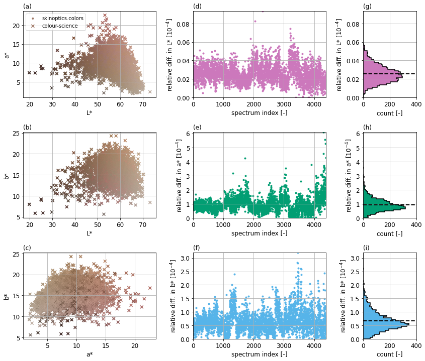

```python
fig, axs = plt.subplots(3, 3,
                        gridspec_kw = {'wspace': 0.35, 'hspace': 0.4, 'width_ratios': [2.5, 2.5, 1]}, figsize = (14, 12))

axs[0,0].scatter(L_sc, a_sc, color = np.dstack((R_sc, G_sc, B_sc))[0,:,:], marker = '.', label = 'skinoptics.colors')
axs[0,0].scatter(L_cs, a_cs, color = np.dstack((R_cs, G_cs, B_cs))[0,:,:], marker = 'x', label = 'colour-science')
axs[0,0].set_xlabel('L*')
axs[0,0].set_ylabel('a*')
axs[0,0].set_title('(a)', loc = 'left')
axs[0,0].legend(loc = 'upper left')

axs[1,0].scatter(L_sc, b_sc, color = np.dstack((R_sc, G_sc, B_sc))[0,:,:], marker = '.')
axs[1,0].scatter(L_cs, b_cs, color = np.dstack((R_cs, G_cs, B_cs))[0,:,:], marker = 'x')
axs[1,0].set_xlabel('L*')
axs[1,0].set_ylabel('b*')
axs[1,0].set_title('(b)', loc = 'left')

axs[2,0].scatter(a_sc, b_sc, color = np.dstack((R_sc, G_sc, B_sc))[0,:,:], marker = '.')
axs[2,0].scatter(a_cs, b_cs, color = np.dstack((R_cs, G_cs, B_cs))[0,:,:], marker = 'x')
axs[2,0].set_xlabel('a*')
axs[2,0].set_ylabel('b*')
axs[2,0].set_title('(c)', loc = 'left')

axs[0,1].scatter(np.arange(n), rel_diff_L_sc_cs*1E4, color = color_cycle[0], marker = '.')
axs[0,1].set_xlabel('spectrum index [-]')
axs[0,1].set_ylabel('relative diff. in L* [10$^{-4}$]')
axs[0,1].set_title('(d)', loc = 'left')
axs[0,1].set_xlim(0, n)
axs[0,1].set_ylim(0, rel_diff_L_sc_cs.max()*1E4)

axs[1,1].scatter(np.arange(n), rel_diff_a_sc_cs*1E4, color = color_cycle[1], marker = '.')
axs[1,1].set_xlabel('spectrum index [-]')
axs[1,1].set_ylabel('relative diff. in a* [10$^{-4}$]')
axs[1,1].set_title('(e)', loc = 'left')
axs[1,1].set_xlim(0, n)
axs[1,1].set_ylim(0, rel_diff_a_sc_cs.max()*1E4)

axs[2,1].scatter(np.arange(n), rel_diff_b_sc_cs*1E4, color = color_cycle[2], marker = '.')
axs[2,1].set_xlabel('spectrum index [-]')
axs[2,1].set_ylabel('relative diff. in b* [10$^{-4}$]')
axs[2,1].set_title('(f)', loc = 'left')
axs[2,1].set_xlim(0, n)
axs[2,1].set_ylim(0, rel_diff_b_sc_cs.max()*1E4)

axs[0,2].hist(rel_diff_L_sc_cs*1E4, bins = 'fd', orientation = 'horizontal', lw = 1.5,
              color = color_cycle[0], alpha = 1., edgecolor = 'k', histtype = 'stepfilled')
axs[0,2].hlines(rel_diff_L_sc_cs.mean()*1E4, 0, 400, color = 'k', ls = '--', lw = 2.)
axs[0,2].set_xlabel('count [-]')
axs[0,2].set_ylabel('relative diff. in L* [10$^{-4}$]')
axs[0,2].set_title('(g)', loc = 'left')
axs[0,2].set_xlim(0, 400)
axs[0,2].set_ylim(0, rel_diff_L_sc_cs.max()*1E4)

axs[1,2].hist(rel_diff_a_sc_cs*1E4, bins = 'fd', orientation = 'horizontal', lw = 1.5,
              color = color_cycle[1], alpha = 1., edgecolor = 'k', histtype = 'stepfilled')
axs[1,2].hlines(rel_diff_a_sc_cs.mean()*1E4, 0, 400, color = 'k', ls = '--', lw = 2.)
axs[1,2].set_xlabel('count [-]')
axs[1,2].set_ylabel('relative diff. in a* [10$^{-4}$]')
axs[1,2].set_title('(h)', loc = 'left')
axs[1,2].set_xlim(0, 400)
axs[1,2].set_ylim(0, rel_diff_a_sc_cs.max()*1E4)

axs[2,2].hist(rel_diff_b_sc_cs*1E4, bins = 'fd', orientation = 'horizontal', lw = 1.5,
              color = color_cycle[2], alpha = 1., edgecolor = 'k', histtype = 'stepfilled')
axs[2,2].hlines(rel_diff_b_sc_cs.mean()*1E4, 0, 400, color = 'k', ls = '--', lw = 2.)
axs[2,2].set_xlabel('count [-]')
axs[2,2].set_ylabel('relative diff. in b* [10$^{-4}$]')
axs[2,2].set_title('(i)', loc = 'left')
axs[2,2].set_xlim(0, 400)
axs[2,2].set_ylim(0, rel_diff_b_sc_cs.max()*1E4)

plt.show()
```

```python
pd.DataFrame(np.array([[rel_diff_L_sc_cs.mean()*1E4],
                       [rel_diff_a_sc_cs.mean()*1E4],
                       [rel_diff_b_sc_cs.mean()*1E4]]),
             index = ['mean relative diff. in L* [10$^{-4}$]',
                      'mean relative diff. in a* [10$^{-4}$]',
                      'mean relative diff. in b* [10$^{-4}$]'],
             columns = ['skinoptics.colors & colour-science'])
```

|  | skinoptics.colors & colour-science |
| --- | --- |
| mean relative diff. in L* [10$^{-4}$] | 0.025814 |
| mean relative diff. in a* [10$^{-4}$] | 0.955426 |
| mean relative diff. in b* [10$^{-4}$] | 0.660821 |

```python
pd.DataFrame(np.array([[rel_diff_L_sc_cs.max()*1E4],
                       [rel_diff_a_sc_cs.max()*1E4],
                       [rel_diff_b_sc_cs.max()*1E4]]),
             index = ['max relative diff. in L* [10$^{-4}$]',
                      'max relative diff. in a* [10$^{-4}$]',
                      'max relative diff. in b* [10$^{-4}$]'],
             columns = ['skinoptics.colors & colour-science'])
```

|  | skinoptics.colors & colour-science |
| --- | --- |
| max relative diff. in L* [10$^{-4}$] | 0.093207 |
| max relative diff. in a* [10$^{-4}$] | 6.104785 |
| max relative diff. in b* [10$^{-4}$] | 3.197917 |

```python
pd.DataFrame(np.array([[rel_diff_L_sc_cs.min()*1E4],
                       [rel_diff_a_sc_cs.min()*1E4],
                       [rel_diff_b_sc_cs.min()*1E4]]),
             index = ['min relative diff. in L* [10$^{-4}$]',
                      'min relative diff. in a* [10$^{-4}$]',
                      'min relative diff. in b* [10$^{-4}$]'],
             columns = ['skinoptics.colors & colour-science'])
```

|  | skinoptics.colors & colour-science |
| --- | --- |
| min relative diff. in L* [10$^{-4}$] | 0.000092 |
| min relative diff. in a* [10$^{-4}$] | 0.001069 |
| min relative diff. in b* [10$^{-4}$] | 0.000639 |

## Color difference

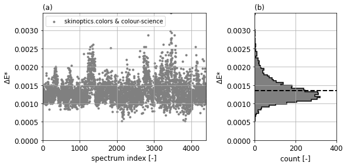

```python
fig, axs = plt.subplots(1, 2,
                        gridspec_kw = {'wspace': 0.4, 'hspace': 0.3,
                                       'width_ratios': [2, 1]}, figsize = (9, 4))

Delta_E_sc_cs = Delta_E(L_sc, a_sc, b_sc, L_cs, a_cs, b_cs)
axs[0].scatter(np.arange(n), Delta_E_sc_cs, color = 'gray', marker = '.', label = 'skinoptics.colors & colour-science')
axs[0].set_xlabel('spectrum index [-]')
axs[0].set_ylabel('$\Delta$E*')
axs[0].legend(loc = 'upper left')
axs[0].set_xlim(0, n)
axs[0].set_ylim(0, Delta_E_sc_cs.max())
axs[0].set_title('(a)', loc = 'left')

axs[1].hist(Delta_E_sc_cs, bins = 'fd', orientation = 'horizontal', lw = 1.5,
            color = 'gray', alpha = 1., edgecolor = 'k', histtype = 'stepfilled')
axs[1].hlines(Delta_E_sc_cs.mean(), 0, 400, color = 'k', ls = '--', lw = 2.)
axs[1].set_xlabel('count [-]')
axs[1].set_ylabel('$\Delta$E*')
axs[1].set_xlim(0, 400)
axs[1].set_ylim(0, Delta_E_sc_cs.max())
axs[1].set_title('(b)', loc = 'left')

plt.show()
```

```python
pd.DataFrame(np.array([[Delta_E_sc_cs.mean()],
                       [Delta_E_sc_cs.max()],
                       [Delta_E_sc_cs.min()]]),
             index = ['mean $\\Delta$E* [-]', 'max $\\Delta$E* [-]', 'min $\\Delta$E* [-]'],
             columns = ['skinoptics.colors & colour-science'])
```

|  | skinoptics.colors & colour-science |
| --- | --- |
| mean $\Delta$E* [-] | 0.001345 |
| max $\Delta$E* [-] | 0.003466 |
| min $\Delta$E* [-] | 0.000527 |

## Extra: ideal grayscale diffuse reflectance standards (DRSs)

\begin{equation} R_d(\lambda) = \alpha \end{equation}

$\alpha \in [0, 1]$, $\lambda \in [360, 830]$ nm

```python
all_alpha = np.arange(100 + 1)
all_lambda = np.arange(360, 830 + 1, 1)
Rd = np.zeros(len(all_lambda))
```

```python
X_DRS_sc, Y_DRS_sc, Z_DRS_sc, R_DRS_sc, G_DRS_sc, B_DRS_sc, L_DRS_sc, a_DRS_sc, b_DRS_sc = np.ones((9, 100 + 1))
for i in range(100 + 1):
    Rd = i*np.ones(len(all_lambda))
    X_DRS_sc[i], Y_DRS_sc[i], Z_DRS_sc[i] = XYZ_from_spectrum(all_lambda, Rd)
    R_DRS_sc[i], G_DRS_sc[i], B_DRS_sc[i] = sRGB_from_spectrum(all_lambda, Rd)
    L_DRS_sc[i], a_DRS_sc[i], b_DRS_sc[i] = Lab_from_spectrum(all_lambda, Rd)
```

```python
X_DRS_cs, Y_DRS_cs, Z_DRS_cs, R_DRS_cs, G_DRS_cs, B_DRS_cs, L_DRS_cs, a_DRS_cs, b_DRS_cs = np.zeros([9, 100 + 1])
for i in range(100 + 1):
    Rd = i*0.01*np.ones(len(all_lambda))
    sd = SpectralDistribution(dict_from_arrays(array_keys = all_lambda, array_values = Rd), name = 'Sample')
    cmfs2 = MSDS_CMFS['CIE 1931 2 Degree Standard Observer']
    cmfs10 = MSDS_CMFS['CIE 1964 10 Degree Standard Observer']
    illuminant = SDS_ILLUMINANTS['D65']
    X_DRS_cs[i], Y_DRS_cs[i], Z_DRS_cs[i] = sd_to_XYZ(sd, cmfs10, illuminant)/100
    R_DRS_cs[i], G_DRS_cs[i], B_DRS_cs[i] = XYZ_to_sRGB(sd_to_XYZ(sd, cmfs2, illuminant)/100)
    L_DRS_cs[i], a_DRS_cs[i], b_DRS_cs[i] = XYZ_to_Lab(sd_to_XYZ(sd, cmfs10, illuminant)/100,
                                                       illuminant = CCS_ILLUMINANTS["CIE 1964 10 Degree Standard Observer"]["D65"])
```

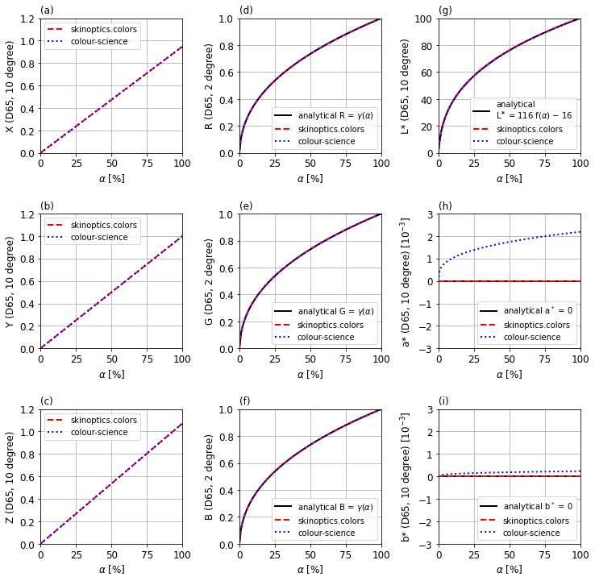

```python
fig, axs = plt.subplots(3, 3,
                        gridspec_kw = {'wspace': 0.4, 'hspace': 0.45}, figsize = (12, 12))

axs[0,0].plot(all_alpha, X_DRS_sc, '--r', lw = 2., label = 'skinoptics.colors')
axs[0,0].plot(all_alpha, X_DRS_cs, ':b', lw = 2., label = 'colour-science')
axs[0,0].set_xlabel('$\\alpha$ [%]')
axs[0,0].set_ylabel('X (D65, 10 degree)')
axs[0,0].set_xlim(0, 100)
axs[0,0].set_ylim(0, 1.2)
axs[0,0].legend(loc = 'upper left')
axs[0,0].set_title('(a)', loc = 'left')

axs[1,0].plot(all_alpha, Y_DRS_sc, '--r', lw = 2., label = 'skinoptics.colors')
axs[1,0].plot(all_alpha, Y_DRS_cs, ':b', lw = 2., label = 'colour-science')
axs[1,0].set_xlabel('$\\alpha$ [%]')
axs[1,0].set_ylabel('Y (D65, 10 degree)')
axs[1,0].set_xlim(0, 100)
axs[1,0].set_ylim(0, 1.2)
axs[1,0].legend(loc = 'upper left')
axs[1,0].set_title('(b)', loc = 'left')

axs[2,0].plot(all_alpha, Z_DRS_sc, '--r', lw = 2., label = 'skinoptics.colors')
axs[2,0].plot(all_alpha, Z_DRS_cs, ':b', lw = 2., label = 'colour-science')
axs[2,0].set_xlabel('$\\alpha$ [%]')
axs[2,0].set_ylabel('Z (D65, 10 degree)')
axs[2,0].set_xlim(0, 100)
axs[2,0].set_ylim(0, 1.2)
axs[2,0].legend(loc = 'upper left')
axs[2,0].set_title('(c)', loc = 'left')

axs[0,1].plot(all_alpha, nonlinear_corr_sRGB(all_alpha/100), 'k', lw = 2., label = 'analytical R = $\\gamma$($\\alpha$)')
axs[0,1].plot(all_alpha, R_DRS_sc, '--r', lw = 2., label = 'skinoptics.colors')
axs[0,1].plot(all_alpha, R_DRS_cs, ':b', lw = 2., label = 'colour-science')
axs[0,1].set_xlabel('$\\alpha$ [%]')
axs[0,1].set_ylabel('R (D65, 2 degree)')
axs[0,1].set_xlim(0, 100)
axs[0,1].set_ylim(0, 1.)
axs[0,1].legend(loc = 'lower right')
axs[0,1].set_title('(d)', loc = 'left')

axs[1,1].plot(all_alpha, nonlinear_corr_sRGB(all_alpha/100), 'k', lw = 2., label = 'analytical G = $\\gamma$($\\alpha$)')
axs[1,1].plot(all_alpha, G_DRS_sc, '--r', lw = 2., label = 'skinoptics.colors')
axs[1,1].plot(all_alpha, G_DRS_cs, ':b', lw = 2., label = 'colour-science')
axs[1,1].set_xlabel('$\\alpha$ [%]')
axs[1,1].set_ylabel('G (D65, 2 degree)')
axs[1,1].set_xlim(0, 100)
axs[1,1].set_ylim(0, 1.)
axs[1,1].legend(loc = 'lower right')
axs[1,1].set_title('(e)', loc = 'left')

axs[2,1].plot(all_alpha, nonlinear_corr_sRGB(all_alpha/100), 'k', lw = 2., label = 'analytical B = $\\gamma$($\\alpha$)')
axs[2,1].plot(all_alpha, B_DRS_sc, '--r', lw = 2., label = 'skinoptics.colors')
axs[2,1].plot(all_alpha, B_DRS_cs, ':b', lw = 2., label = 'colour-science')
axs[2,1].set_xlabel('$\\alpha$ [%]')
axs[2,1].set_ylabel('B (D65, 2 degree)')
axs[2,1].set_xlim(0, 100)
axs[2,1].set_ylim(0, 1.)
axs[2,1].legend(loc = 'lower right')
axs[2,1].set_title('(f)', loc = 'left')

axs[0,2].plot(all_alpha, 116*f_Lab_from_XYZ(all_alpha/100) - 16, 'k', lw = 2., label = 'analytical\nL$^∗$ = 116 f($\\alpha$) − 16')
axs[0,2].plot(all_alpha, L_DRS_sc, '--r', lw = 2., label = 'skinoptics.colors')
axs[0,2].plot(all_alpha, L_DRS_cs, ':b', lw = 2., label = 'colour-science')
axs[0,2].set_xlabel('$\\alpha$ [%]')
axs[0,2].set_ylabel('L* (D65, 10 degree)')
axs[0,2].set_xlim(0, 100)
axs[0,2].set_ylim(0, 100)
axs[0,2].legend(loc = 'lower right')
axs[0,2].set_title('(g)', loc = 'left')

axs[1,2].plot(all_alpha, np.zeros(len(all_alpha)), 'k', lw = 2., label = 'analytical a$^*$ = 0')
axs[1,2].plot(all_alpha, a_DRS_sc*1E3, '--r', lw = 2., label = 'skinoptics.colors')
axs[1,2].plot(all_alpha, a_DRS_cs*1E3, ':b', lw = 2., label = 'colour-science')
axs[1,2].set_xlabel('$\\alpha$ [%]')
axs[1,2].set_ylabel('a* (D65, 10 degree) [10$^{-3}$]')
axs[1,2].set_xlim(0, 100)
axs[1,2].set_ylim(-3, 3)
axs[1,2].legend(loc = 'lower right')
axs[1,2].set_title('(h)', loc = 'left')

axs[2,2].plot(all_alpha, np.zeros(len(all_alpha)), 'k', lw = 2., label = 'analytical b$^*$ = 0')
axs[2,2].plot(all_alpha, b_DRS_sc*1E3, '--r', lw = 2., label = 'skinoptics.colors')
axs[2,2].plot(all_alpha, b_DRS_cs*1E3, ':b', lw = 2., label = 'colour-science')
axs[2,2].set_xlabel('$\\alpha$ [%]')
axs[2,2].set_ylabel('b* (D65, 10 degree) [10$^{-3}$]')
axs[2,2].set_xlim(0, 100)
axs[2,2].set_ylim(-3, 3)
axs[2,2].legend(loc = 'lower right')
axs[2,2].set_title('(i)', loc = 'left')

plt.show()
```

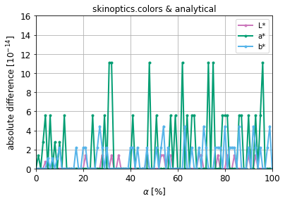

```python
plt.plot(all_alpha, np.abs(L_DRS_sc - (116*f_Lab_from_XYZ(all_alpha/100) - 16))*1E14,
            color = color_cycle[0], marker = '.', lw = 2., label = 'L*')
plt.plot(all_alpha, np.abs(a_DRS_sc - np.zeros(len(all_alpha)))*1E14,
            color = color_cycle[1], marker = '.', lw = 2., label = 'a*')
plt.plot(all_alpha, np.abs(b_DRS_sc - np.zeros(len(all_alpha)))*1E14,
            color = color_cycle[2], marker = '.', lw = 2., label = 'b*')
plt.xlabel('$\\alpha$ [%]')
plt.ylabel('absolute difference [10$^{-14}$]')
plt.title('skinoptics.colors & analytical')
plt.xlim(0, 100)
plt.ylim(0, 16)
plt.legend(loc = 'upper right')
plt.show()
```